# Bayesian Random-effects Meta Regression

Author

Ananda Biswas

Published

October 29, 2026

## Required Libraries

**Show/Hide Code**

```r
library(openxlsx)

library(gt)
library(tidyverse)

library(cmdstanr)

library(bayesplot)
```

## Loading Data

**Show/Hide Code**

```r
df1 <- read.xlsx(data.path, sheet = 1)
```

## Initial Sanity Checks

**Show/Hide Code**

```r
str(df1)
```

```
'data.frame':   18 obs. of  10 variables:
 $ Study           : chr  "Czuczman, 2017" "Aribi, 2010" "Pettengell, 2020" "Shi, 2020" ...
 $ Sample.n1       : num  51 48 155 22 70 40 222 180 112 42 ...
 $ Sample.n2       : num  51 48 157 20 70 40 223 179 118 39 ...
 $ Follow-up.months: num  NA 13 NA 45 18 48.9 10.9 47.2 15.5 10 ...
 $ HR.OS           : num  0.91 0.45 1.13 0.228 0.79 0.42 0.9 0.73 0.63 1.17 ...
 $ OS.ln.HR        : num  -0.041 -0.3565 0.0531 -0.6421 -0.1024 ...
 $ OS.se           : num  0.209 0.112 0.179 0.252 0.166 ...
 $ HR.PFS          : num  0.64 0.44 0.85 0.398 0.6 0.39 1.12 0.51 0.53 1.29 ...
 $ PFS.ln.HR       : num  -0.1938 -0.3565 -0.0706 -0.4001 -0.2218 ...
 $ PFS.se          : num  0.148 0.107 0.128 0.206 0.112 ...
```

**Show/Hide Code**

```r
dim(df1)
```

```
[1] 18 10
```

RR-DLBCL Data

| Study | Sample.n1 | Sample.n2 | Follow-up.months | HR.OS | OS.ln.HR | OS.se | HR.PFS | PFS.ln.HR | PFS.se |
| --- | --- | --- | --- | --- | --- | --- | --- | --- | --- |
| Czuczman, 2017 | 51.0000 | 51.0000 | NA | 0.9100 | −0.0410 | 0.2092 | 0.6400 | −0.1938 | 0.1480 |
| Aribi, 2010 | 48.0000 | 48.0000 | 13.0000 | 0.4500 | −0.3565 | 0.1122 | 0.4400 | −0.3565 | 0.1071 |
| Pettengell, 2020 | 155.0000 | 157.0000 | NA | 1.1300 | 0.0531 | 0.1786 | 0.8500 | −0.0706 | 0.1276 |
| Shi, 2020 | 22.0000 | 20.0000 | 45.0000 | 0.2280 | −0.6421 | 0.2518 | 0.3980 | −0.4001 | 0.2061 |
| Pettengell, 2012 | 70.0000 | 70.0000 | 18.0000 | 0.7900 | −0.1024 | 0.1658 | 0.6000 | −0.2218 | 0.1122 |
| Sehn, 2022 | 40.0000 | 40.0000 | 48.9000 | 0.4200 | −0.3768 | 0.1224 | 0.3900 | −0.4089 | 0.1097 |
| Van Imhoff, 2017 | 222.0000 | 223.0000 | 10.9000 | 0.9000 | −0.0458 | 0.1148 | 1.1200 | 0.0492 | 0.1352 |
| Westin, 2023 | 180.0000 | 179.0000 | 47.2000 | 0.7300 | −0.1367 | 0.1122 | 0.5100 | −0.2924 | 0.0740 |
| Bartlett, 2025 | 112.0000 | 118.0000 | 15.5000 | 0.6300 | −0.2007 | 0.1122 | 0.5300 | −0.2757 | 0.0893 |
| Morschhauser, 2019 | 42.0000 | 39.0000 | 10.0000 | 1.1700 | 0.0682 | 0.3673 | 1.2900 | 0.1106 | 0.3520 |
| Abramson, 2024 | 183.0000 | 91.0000 | 20.7000 | 0.6200 | −0.2076 | 0.1148 | 0.4000 | −0.3979 | 0.0740 |
| Vose, 2013 | 111.0000 | 113.0000 | 25.5000 | 1.1400 | 0.0569 | 0.2679 | 1.0800 | 0.0334 | 0.1990 |
| Ramchandren, 2023 | 55.0000 | 34.0000 | NA | 0.8300 | −0.0809 | 0.2423 | 0.8800 | −0.0555 | 0.2590 |
| Gisselbrecht, 2010 | 202.0000 | 194.0000 | 27.0000 | 1.2800 | 0.1072 | 0.1760 | 1.0700 | 0.0294 | 0.1352 |
| Kamdar, 2025 | 92.0000 | 92.0000 | 33.9000 | 0.7570 | −0.1209 | 0.1811 | 0.4220 | −0.3747 | 0.0918 |
| Kong, 2023 | 35.0000 | 21.0000 | 12.0000 | 0.7900 | −0.1024 | 0.3342 | 0.6400 | −0.1938 | 0.3061 |
| Zhang, 2024 | 28.0000 | 14.0000 | 7.5000 | 0.5500 | −0.2596 | 0.2934 | 0.5000 | −0.3010 | 0.2066 |
| Ying, 2023 | 27.0000 | 31.0000 | 17.9000 | 0.6600 | −0.1805 | 0.3900 | 0.7100 | −0.1487 | 0.2679 |

## Derived Quantities

**Show/Hide Code**

```r
df1$weight <- 1 / (df1$OS.se)^2
```

## Generating Treatment Effect on Surrogate Endpoint in New Trials

**Show/Hide Code**

```r
range(df1$HR.PFS)
```

```
[1] 0.39 1.29
```

**Show/Hide Code**

```r
# Suppose 1000 new trials reporting TE on surrogate endpoint only
new.data <- data.frame(PFS.ln.HR = log(seq(0.39, 1.3, length=1000)))
```

## Model

A random-effects meta-analysis allows for the differences in the treatment effect between studies. In a Bayesian random-effects meta-regression framework, the model can be written as

$$Y_{2i}
\sim
N\left(\mu_{2i},\sigma_{2i}^2\right),
\qquad
i=1,\ldots,N,$$

where the mean (study-specific treatment effect) is modeled as

$$\mu_{2i}
=
\lambda_{0i}
+
\lambda_1 Y_{1i}.$$

The study-specific intercepts are assumed to follow a common Normal distribution:

$$\lambda_{0i}
\sim
N\left(\beta,\psi^2\right).$$

Here:

- $Y_{1i}$ = summary measure of the treatment effect on the candidate surrogate outcome in study $i$;
- $Y_{2i}$ = summary measure of the treatment effect on the target outcome in study $i$;
- $\mu_{2i}$ = underlying true treatment effect on the target outcome in study $i$;
- $\sigma_{2i}$ = standard deviation of the estimated treatment effect $Y_{2i}$;
- $\lambda_{0i}$ = study-specific true effect on the target outcome when the treatment effect on the surrogate is zero;
- $\lambda_1$ = regression coefficient describing the relationship between treatment effects on the surrogate and target outcomes;
- $\beta$ = mean of the overarching distribution of the study-specific intercepts; and
- $\psi^2$ = between-study variance representing heterogeneity in the study-specific intercepts.

In the Bayesian framework, all parameters are given prior distributions :

$$\beta \sim N(0,10^2),$$

$$\lambda_1 \sim N(0,10^2),$$

$$\psi \sim \operatorname{Half}\text{-}t_3(0,2.5), \qquad \psi > 0,$$

and

$$\lambda_{0i}^{\mathrm{raw}} \sim N(0,1),
\qquad i=1,\ldots,N.$$

## Surrogacy Criteria

A perfect surrogate requires all the following conditions simultaneously :

- $\beta = 0$, to ensure that no treatment effect on the surrogate endpoint implies no treatment effect on the final clinical outcome
- $\lambda_1 \neq 0$, establishing a relationship between treatment effects on the surrogate and final clinical outcomes
- $\psi^2 = 0$, implying that one can predict $\mu_{2i}$ perfectly given $Y_{1i}$.

## Model Fitting

### Preparing data for STAN

**Show/Hide Code**

```r
STAN_data.BREMR <- list(
  N = nrow(df1),
  Y2 = df1$OS.ln.HR,
  Y1 = df1$PFS.ln.HR,
  sigma2 = df1$OS.se
)
```

### STAN Model

Here is a suitable STAN model.

```stan
data {
  int<lower = 1> N;

  vector[N] Y2;
  vector[N] Y1;

  vector<lower = 0>[N] sigma2;
}

parameters {
  real beta;
  real lambda1;
  real<lower = 0> psi;

  vector[N] lambda0_raw;
}

transformed parameters {
  vector[N] lambda0;
  vector[N] mu2;

  lambda0 = beta + psi * lambda0_raw;
  mu2 = lambda0 + lambda1 * Y1;

  real<lower = 0> psi_sq = square(psi);
}

model {
  // Priors
  beta ~ normal(0, 10);
  lambda1 ~ normal(0, 10);
  psi ~ student_t(3, 0, 2.5);

  lambda0_raw ~ std_normal();

  // Sampling distribution
  Y2 ~ normal(mu2, sigma2);
}

generated quantities {
  vector[N] Y2_rep;

  for (i in 1:N) {
    Y2_rep[i] = normal_rng(mu2[i], sigma2[i]);
  }
}
```

### Model Compilation

**Show/Hide Code**

```r
model.BREMR <- cmdstan_model(stan_file = BREMR.model.file)
```

### Running HMC

**Show/Hide Code**

```r
n.chains <- 4
n.samples.per.chain <- 100000
```

**Show/Hide Code**

```r
fit.BREMR <- model.BREMR$sample(
  data = STAN_data.BREMR,
  chains = n.chains,
  parallel_chains = n.chains,
  iter_warmup = 25000,
  iter_sampling = n.samples.per.chain,
  adapt_delta = 0.96,
  seed = 14,
  refresh = 0 # suppress the iteration progress messages
)
```

```
Running MCMC with 4 parallel chains...

Chain 4 finished in 19.6 seconds.
Chain 1 finished in 22.1 seconds.
Chain 3 finished in 23.3 seconds.
Chain 2 finished in 23.8 seconds.

All 4 chains finished successfully.
Mean chain execution time: 22.2 seconds.
Total execution time: 23.9 seconds.
```

**Show/Hide Code**

```r
n.posterior.samples <- n.chains * n.samples.per.chain
```

### STAN Diagnostics

**Show/Hide Code**

```r
fit.BREMR$cmdstan_diagnose()
```

```
Checking sampler transitions treedepth.
Treedepth satisfactory for all transitions.

Checking sampler transitions for divergences.
No divergent transitions found.

Checking E-BFMI - sampler transitions HMC potential energy.
E-BFMI satisfactory.

Rank-normalized split effective sample size satisfactory for all parameters.

Rank-normalized split R-hat values satisfactory for all parameters.

Processing complete, no problems detected.
```

### Posterior Predictive Check - PPC

It is a way of checking whether my Bayesian model can generate data that look reasonably similar to the data I actually observed.

Suppose we observe $n$ data-points. For each posterior draw of the parameters, we draw a random sample of $n$ data-points.

**Show/Hide Code**

```r
Y2.replicated.draws <- fit.BREMR$draws(variables = "Y2_rep", format = "matrix")

dim(Y2.replicated.draws)
```

```
[1] 400000     18
```

### Check 1

Plot the density of the observed data and densities of a few randomly selected replicated data-sets to assess the Bayesian model.

**Show/Hide Code**

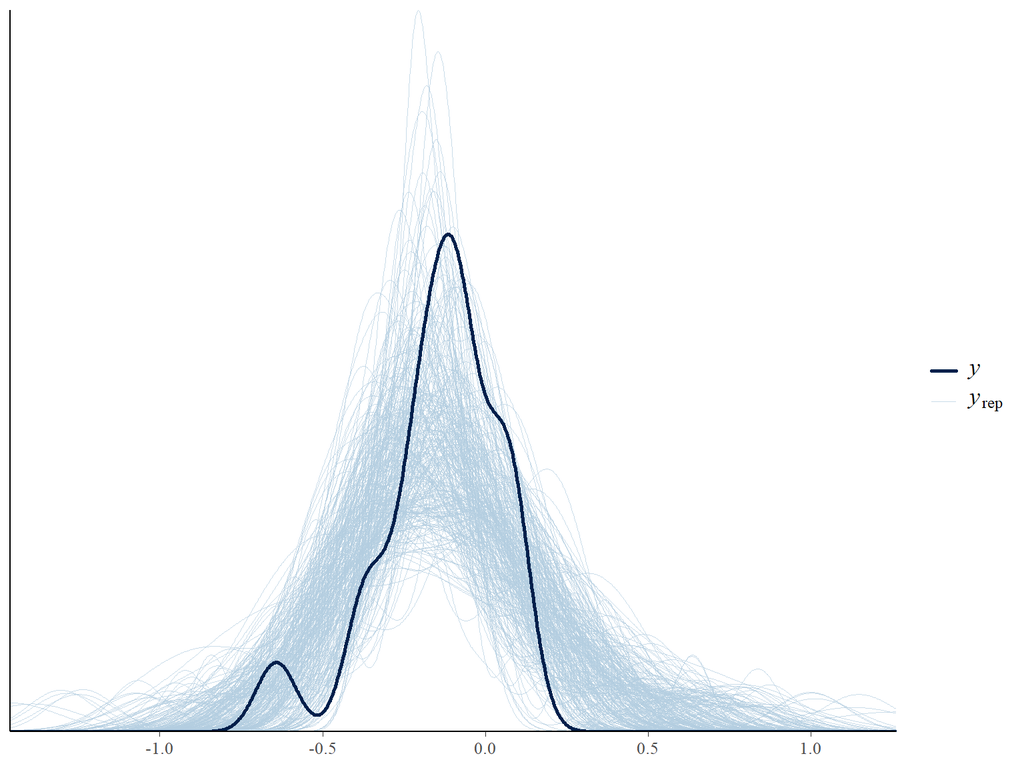

```r
# a few randomly selected replications
temp <- sample(1:n.posterior.samples, 300)

ppc_dens_overlay(y = df1$OS.ln.HR,
                 yrep = Y2.replicated.draws[temp, ])
```

The thin colored lines are supposed to closely envelope the thick dark line. The above is not of course the greatest fit, but not a poor fit as well.

### Check 2

Plot the observed `y~x` along with the prediction intervals calculated from the replications of each `y`.

**Show/Hide Code**

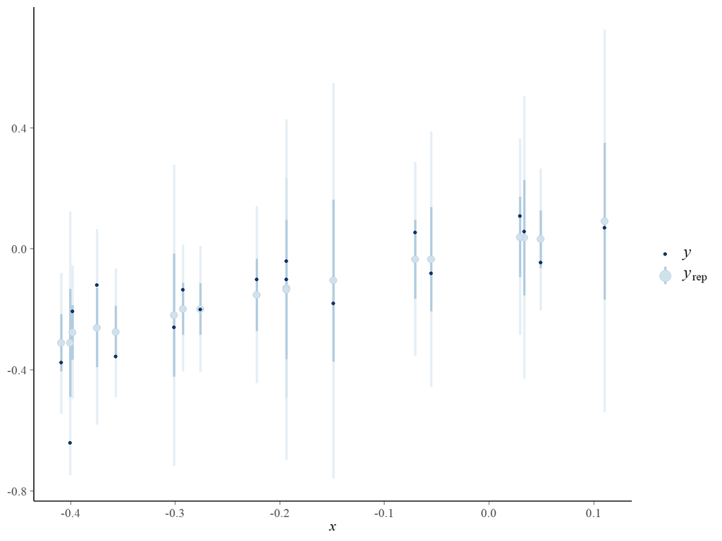

```r
ppc_intervals(y = df1$OS.ln.HR,
              yrep = Y2.replicated.draws,
              x = df1$PFS.ln.HR)
```

In the above, all the wide outer bands often contain the dark dots.

## Posterior Summaries of Parameters of Interest

### Posterior Draws

**Show/Hide Code**

```r
posterior.draws <- fit.BREMR$draws(
  variables = c("beta", "lambda1", "psi_sq"),
  format = "matrix"
)
```

### Point Estimates

**Show/Hide Code**

```r
apply(posterior.draws, 2, mean)
```

```
       beta     lambda1      psi_sq
0.010256784 0.758937108 0.003959886
```

### Interval Estimates

**Show/Hide Code**

```r
apply(posterior.draws, 2, quantile, probs = c(0.025, 0.975))
```

```
       variable
              beta   lambda1       psi_sq
  2.5%  -0.1318500 0.2599513 3.580208e-06
  97.5%  0.1544238 1.2652941 2.111207e-02
```

## Prediction of TE on Clinical Outcome in New Trials

Now use posterior samples to calculate the predictions on new future trials, credible intervals and prediction intervals. These are the main components of **trial-level association plot**.

**Show/Hide Code**

```r
data.frame(head(posterior.draws)) |>
  gt()
```

Preview of Posterior Sample

| beta | lambda1 | psi_sq |
| --- | --- | --- |
| 0.064904481 | 1.0139992 | 0.004281130 |
| 0.089292387 | 0.9079285 | 0.001225358 |
| -0.009059908 | 0.7759304 | 0.005348943 |
| -0.027932057 | 0.7472080 | 0.003762119 |
| -0.054504039 | 0.6621536 | 0.005739100 |
| 0.037841389 | 0.8249063 | 0.002624232 |

**Show/Hide Code**

```r
dim(posterior.draws)
```

```
[1] 400000      3
```

Each row of `posterior.draws` is a posterior sample from the joint posterior distribution of the parameters.

Now I create a design matrix `X` representing new studies on which we will make future predictions.

**Show/Hide Code**

```r
X <- matrix(c(rep(1, 1000), new.data$PFS.ln.HR),
            nrow = 1000, ncol = 2, byrow = FALSE)
```

For each new trial in `X`, corresponding to $400000$ posterior samples of the parameters, there will be $400000$ predictions of `log.HR.OS`. Below I do a matrix operation to obtain all the $1000 \times 400000$ predictions.

**Show/Hide Code**

```r
BREMR.posterior <- X %*% t(posterior.draws[,1:2])
```

**Show/Hide Code**

```r
dim(BREMR.posterior)
```

```
[1]   1000 400000
```

Each row of `BREMR.posterior` represents $400000$ posterior draws of `log.HR.OS` *i.e.* the response variable, corresponding to a new `log.HR.PFS` of a new trial.

### Point Estimates

For a new trial, to get a prediction of `log.HR.OS`, we must calculate the mean of the posterior samples.

**Show/Hide Code**

```r
BREMR.fit <- apply(BREMR.posterior, 1, mean)
```

`BREMR.fit` has $1000$ predictions corresponding to $1000$ new future trials.

### Credible Intervals

Credible intervals are obtained from the quantiles of the posterior distribution. Here I calculate the $95\%$ credible intervals for the predictions on new trials.

**Show/Hide Code**

```r
BREMR.ci <- t(apply(BREMR.posterior, 1, quantile, probs = c(0.025, 0.975)))
```

### Prediction Intervals

Prediction intervals are obtained from the quantiles of the posterior predictive distribution.

The posterior distribution of concern here is

$$p\left(\beta, \lambda_1, \psi \mid Y_{11}, Y_{21}, Y_{12}, Y_{22}, \ldots, Y_{1N}, Y_{2N}\right).$$
Already I have $400000$ samples from this posterior distribution.

We want the predictive distribution of $\widehat{\mu_{2 \cdot \text{new}}}:$ the true treatment effect on clinical outcome in a future trial.

In any future trial, let $Y_{1 \cdot \text{new}}$ be the observed treatment effect on surrogate endpoint. Then we must have

$$\widehat{\mu_{2 \cdot \text{new}}} \sim \mathcal{N}\left( \beta + \lambda_1 Y_{1 \cdot \text{new}}, \psi^2\right).$$

In Bayesian theory, the predictive distribution is obtained by averaging the likelihood over the entire parameter space where the parameters vary in accordance to the posterior distribution.

Mathematically, we can write the posterior predictive distribution as

$$\displaystyle{\int \limits_{(\beta, \lambda_1, \psi)}} \mathcal{N}\left( \beta + \lambda_1 Y_{1 \cdot \text{new}}, \psi^2\right) \cdot p\left(\beta, \lambda_1, \psi \mid \cdots \right) d\beta \; d\lambda_1 \; d\psi.$$

As analytical solution cannot be traced, we resort to numerical solution as follows :

- Using posterior sample $(\beta_{(m)}, \lambda_{1(m)}, \psi_{(m)})$ calculate $\beta_{(m)} + \lambda_{1(m)} Y_{1 \cdot \text{new}}$ $\forall m = 1(1)400000$.
- Take a random sample from $\mathcal{N}\left(\beta_{(m)} + \lambda_{1(m)}, \psi_{(m)}^2 \right)$ $\forall m = 1(1)400000$.
- Calculate $q_{0.025}$, $q_{0.975}$ for the random samples just obtained.
- Repeat the above $3$ for all the new trials to get predictive interval around their predictions.

Now I proceed to calculate the $95\%$ posterior prediction intervals.

**Show/Hide Code**

```r
posterior.draws.psi <- fit.BREMR$draws(variables = "psi", format = "matrix")

u <- rnorm(n.posterior.samples, 0, sd = posterior.draws.psi[,1])

BREMR.predictions <- BREMR.posterior +
                     matrix(rep(u, 1000),
                            nrow = 1000,
                            ncol = n.posterior.samples,
                            byrow = TRUE)
```

**Show/Hide Code**

```r
BREMR.pi <- t(apply(BREMR.predictions, 1, quantile, probs = c(0.025, 0.975)))
```

## Trial-level Association Plot

I combine all the required components for the trial-level association plot.

**Show/Hide Code**

```r
BREMR.pred.df <- data.frame(HR.OS = exp(BREMR.fit),
                            HR.PFS = exp(new.data$PFS.ln.HR),
                            lower.ci = exp(BREMR.ci[,1]),
                            upper.ci = exp(BREMR.ci[,2]),
                            lower.pi = exp(BREMR.pi[,1]),
                            upper.pi = exp(BREMR.pi[,2]))
```

**Show/Hide Code**

```r
BREMR.association.plot <- ggplot(df1, aes(x = HR.PFS, y = HR.OS)) +
  geom_ribbon(aes(x = HR.PFS, ymin = lower.ci, ymax = upper.ci), data = BREMR.pred.df, alpha = 0.6, fill = "#D2D808") +
  geom_ribbon(aes(x = HR.PFS, ymin = lower.pi, ymax = upper.pi), data = BREMR.pred.df, alpha = 0.4, fill = "#EEF255") +
  geom_line(aes(x = HR.PFS, y = HR.OS), data = BREMR.pred.df,
            col = "#999E0E", linewidth = 1, stat = 'identity') +
  geom_point(aes(size = weight), col = "#454545", fill = "#9E235E", shape = 21, data = df1) +
  scale_x_continuous(transform = "log",
                     limits = c(0.38, 1.3),
                     breaks=c(0.3,0.4,0.5,0.7,1,1.2),
                     expand = c(0.01, 0.01)) +
  scale_y_continuous(transform = "log",
                     limits = c(0.2, 2.0),
                     breaks=c(0.2,0.3,0.4,0.5,0.7,1,1.2,1.5,2),
                     expand = c(0.01, 0.01)) +
  geom_hline(yintercept = 1, linetype = "dashed") +
  xlab("Progression-free survival hazard ratio (log scale)")+
  ylab(paste("Overall survival hazard ratio" , "\n", "\U00B1", "95% credible and prediction intervals (log scale)")) +
  ggtitle("Bayesian Random-effects Meta-regression") +
  theme_bw() +
  scale_colour_hue("trial") +
  theme(legend.position = "none",
        axis.title.x = element_text(size = 14, color = "#6A1A41", face = "bold"),
        axis.title.y = element_text(size = 14, color = "#6A1A41", face = "bold"),
        plot.title = element_text(size = 15, face = "bold"))
```

**Show/Hide Code**

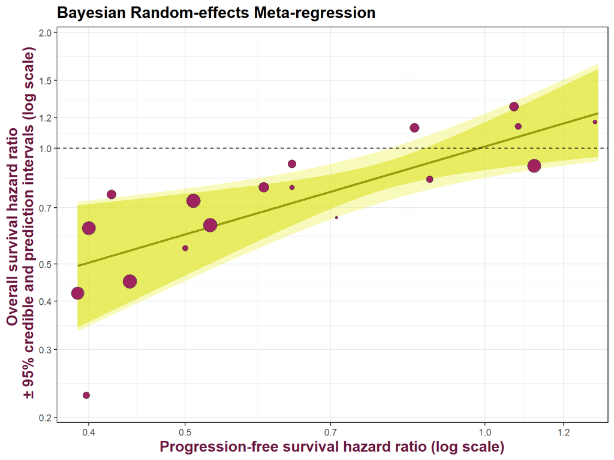

```r
BREMR.association.plot
```

## Surrogate Threshold Effect

**Show/Hide Code**

```r
candidate.HR.PFS <- BREMR.pred.df %>%
  filter(upper.pi < 1) %>%
  pull(HR.PFS)

BREMR.STE <- max(candidate.HR.PFS)
BREMR.STE |> round(3)
```

```
[1] 0.803
```

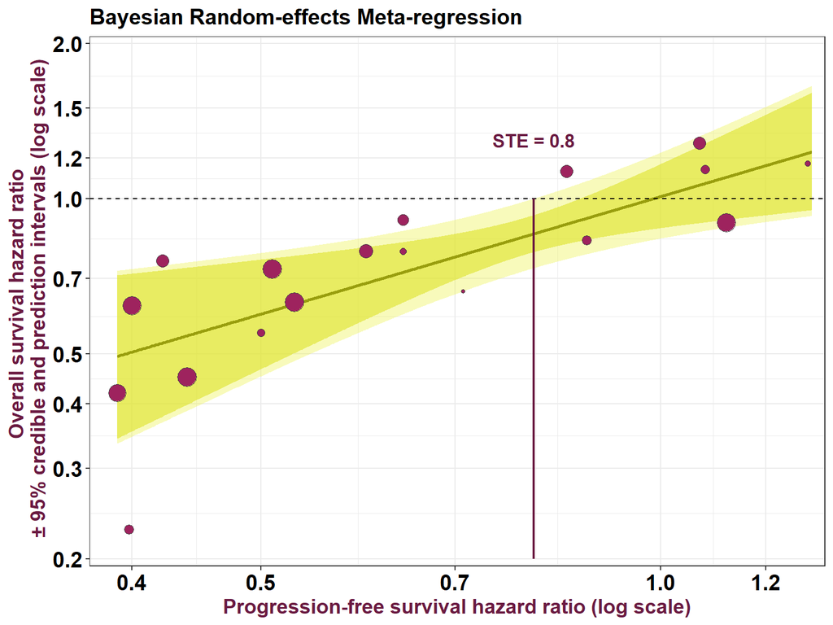